# Identification of Alternative Splicing and polyadenylation in bulk RNA-seq data

Gunjan

22/01/2021

# Introduction

NOTE: The context of this R notebook includes all the R code requied for the analysis of Differential splicing analysis of bulk RNA-Seq data. Refer to the PART 1- Bulk RNA-Seq analysis of the Protocol section.

# 1. Data downloading and pre-processing

The raw data can be downloaded from Sequence Read Archive [SRA] using the ‘prefetch’ command from SRA toolkit. Give the SRA Accession Ids in sequence in the following command to download them in parallel using GNU parallel. Once you have the raw files, extract the fastq files from these archive files with the help of ‘fastq-dump’. Download the required reference genome and annotation from www.ensembl.org. For the pre-processing step, quality check was performed using the ‘FASTQC’ followed by mapping of reads to the reference genome using ‘STAR’ aligner. Refer to the supplementary file- “downloading_data_preprocessing.sh” for step by step procedure.

To download SRA files of accession ids from SRR10261601 to SRR10261606 in parallel, type the following commands on the terminal-

```bash
seq 10261601 10261606 | parallel prefetch SRR{}
parallel -j 3 fastq-dump --gzip --skip-technical --read-filter pass --dumpbase --split-e --clip --origfmt {} ::: <name of sra files together>
```

The reference genome and annotations for Mouse (Genome assembly GRCm39) were downloaded from www.ensembl.org.

```bash
wget -nv -O annotation.gtf.gz http://ftp.ensembl.org/pub/release-103/gtf/mus_musculus/Mus_musculus.GRCm39.103.gtf.gz \ && gunzip -f annotation.gtf.gz

wget -nv -O genome.fa.gz http://ftp.ensembl.org/pub/release-103/fasta/mus_musculus/dna/Mus_musculus.GRCm39.dna.primary_assembly.fa.gz \ && gunzip -f genome.fa.gz
GTF=$(readlink -f annotation.gtf)
GENOME=$(readlink -f genome.fa)
```

## 1.2 Pre-processing

### 1.2.1 Quality Control

The initial quality check was performed using FASTQC (v0.11.9). This will generate individual html files for each sample with a quality report.

```bash
mkdir fastqc_out
parallel "fastqc {} -o fastqc_out" ::: $RAW_DATA/*.fastq.gz
```

### 1.2.2 Read alignment

The next step in pre-processing includes mapping the reads to the reference genome. We first build the index for the reference genome and then use read pairs to align them (alternatively prebuilt indexes are available from the STAR web13. STAR (v2.7.5c) aligner was used for this purpose.

Run the following commands as a bash script.

```bash
#Build STAR index
GDIR=STAR_indices
mkdir $GDIR
STAR --runMode genomeGenerate --genomeFastaFiles $GENOME --sjdbGTFfile $GTF --runThreadN 8 --genomeDir $GDIR
ODIR=results/mapping
mkdir -p $ODIR
#Align reads to the genome
for fq1 in $RAW_DATA/*R1.fastq.gz;
do
fq2=$(echo $fq1 | sed 's/1.fastq.gz/2.fastq.gz/g');
OUTPUT=$(basename ${fq1}| sed 's/R1.fastq.gz//g');
STAR --genomeDir $GDIR \
 --runThreadN 12 \
 --readFilesCommand zcat \
 --readFilesIn  ${fq1} ${fq2}\
 --outFileNamePrefix $ODIR\/${OUTPUT} \
 --outSAMtype BAM SortedByCoordinate \
 --outSAMunmapped Within \
 --outSAMattributes Standard
Done
```

We now have sorted BAM files for further analysis.

# 2. Preparing Exon annotations

Run the supplemntary file- “prepare_mm10_exon_annotation.R” with the downloaded annotation in GTF format on the terminal to prepare the annotations. To run this file type this in terminal Save the given code as ‘prepare_mm10_exon_annotation.R’ file and run it on the terminal- Rscript prepare_mm10_exon_annotation.R annotation.gtf

```r
#! /usr/bin/env Rscript
#To run- Rscript prepare_mm10_annotation.R <GTF_file>
library(rtracklayer)
library(tidyverse)
args = commandArgs(trailingOnly = TRUE)
gff_mm10 <- args[1]
mgg <- import(gff_mm10)

anno = mgg %>% data.frame %>%
  mutate(seqnames = as.character(seqnames)) %>%
  dplyr::filter(!grepl("chr[1-19]|X|Y", seqnames)) %>%
  filter(type %in% "exon") %>%
  select(seqnames, start,   end ,width, strand, gene_name,  transcript_id)  %>% distinct() %>%
  group_by(gene_name, seqnames, start, end, width, strand) %>%
  summarise(transcript_ids = paste(transcript_id, sep="",collapse=",")) %>%
  ungroup()  %>%
  mutate(number = 1) %>%
  arrange( seqnames,   start ,    end) %>%  group_by(gene_name, seqnames) %>% #
  mutate(ticker = cumsum(number)) %>%
  mutate(ExonID = paste(gene_name, ".",seqnames,".", ticker, sep="")) %>%
  dplyr::select(-number, ticker) %>%
  add_count(gene_name) %>%
  data.frame
colnames(anno) <- c("GeneID", "Chr", "Start", "End", "Width", "Strand", "TranscriptIDs", "Ticker", "ExonID", "n")
save(anno, file=paste("mm10_exon_anno.RData", sep=""))
```

The GTF file contains multiple exon entries for different transcripts. This file is used to ‘collapse’ the multiple transcript IDs for each exon using a comma. It is an important step to define exon counting bins and to retain the information about overlapping genes.

# 3 Counting Reads

For counting the number of reads mapped to different exons, featureCounts from the Rsubread package was used.

### 3.1 Load required libraries-

The following packages were used for this part of the analysis. Make sure to install the packages if they are not already installed.

```r
packages <- c("DEXSeq","Rsubread","tibble", "dplyr", "EnhancedVolcano", "edgeR")

#Load libraries
invisible(lapply(packages, library, character.only = TRUE))
```

### 3.2 Load the processed annotation file-

```r
load("mm10_exon_anno.RData")
```

### 3.3 Read the bam files obtained in step 1.2.2(after mapping) as input for featureCounts.

Before running this step, make sure you have the folder containing bam files in the current working directory.

```r
# Read all bam files as input for featureCounts
filesToCount <- dir("bams", pattern=".bam$", full.names=T)
countData <- featureCounts(filesToCount, annot.ext=anno, isGTFAnnotationFile=FALSE, minMQS=0, useMetaFeatures=FALSE, allowMultiOverlap=TRUE, largestOverlap = TRUE, countMultiMappingReads=FALSE, primaryOnly=TRUE, isPairedEnd=TRUE, nthreads = 12)
```

[output not shown]

[output cut: 25 more lines]

```
||    Paired-end reads are included.                                          ||
||    Total alignments : 67020773                                             ||
||    Successfully assigned alignments : 36912956 (55.1%)                     ||
||    Running time : 0.74 minutes                                             ||
||                                                                            ||
|| Process BAM file WT_Thymus_3.bam...                                        ||
||    Paired-end reads are included.                                          ||
||    Total alignments : 63809561                                             ||
||    Successfully assigned alignments : 35624260 (55.8%)                     ||
||    Running time : 0.71 minutes                                             ||
||                                                                            ||
|| Write the final count table.                                               ||
|| Write the read assignment summary.                                         ||
||                                                                            ||
\\============================================================================//
```

```r
# Non-specific filtering: Remove the exons with low counts
isexpr <- rownames(countData$counts)[rowSums(cpm(countData$counts) > 1) >= 3]
countData$counts <- countData$counts[rownames(countData$counts) %in% isexpr, ]
anno <- anno %>% filter(GeneID %in% rownames(countData$counts))

# Remove genes with only 1 site and  NA in geneIDs
dn <- anno %>% group_by(GeneID) %>% summarise(nsites=n())  %>% filter(nsites > 1 & !is.na(GeneID))
anno <- anno %>% filter(GeneID %in% dn$GeneID)
countData$counts <- countData$counts[rownames(countData$counts) %in% anno$GeneID, ]
```

# 4. Differential Splicing and Exon usage analysis

## 4.1 Using DEXSeq pipeline for differential exon analysis

### 4.1.1 Load library and create a sample table to define the experimental design

```r
library(DEXSeq)
sampleTable = data.frame(
   row.names = c( "Mbnl1KO_Thymus_1", "Mbnl1KO_Thymus_2", "Mbnl1KO_Thymus_3",
                 "WT_Thymus_1", "WT_Thymus_2", "WT_Thymus_3" ),
   condition = rep(c("Mbnl1_KO", "WT"),c(3,3)),
   libType = rep(c("paired-end")))
```

NOTE: The row names should be consistent with the bam file names used by featureCounts to count the reads. sampleTable consists of details of each sample which includes- library-type and condition. This is required to define the contrasts or test group for detecting differential usage.

### 4.1.2 Prepare the exon information file

Exon information in form of GRanges object is required as an input to create DEXSeq object. Match the gene Ids with the read counts and extract their specific annotation present in the prepared annotation object to create exoninfo object.

```r
exoninfo = anno[anno$GeneID %in% rownames(countData$counts),]
exoninfo <- GRanges (seqnames=  anno$Chr,
ranges= IRanges (start=anno$Start, end=anno$End, width = anno$Width), strand = Rle(anno$Strand))
mcols(exoninfo)$TranscriptIDs <- anno$TranscriptIDs
mcols(exoninfo)$Ticker <- anno$Ticker
mcols(exoninfo)$ExonID <- anno$ExonID
mcols(exoninfo)$n <- anno$n
mcols(exoninfo)$GeneID <- anno$GeneID

transcripts_l = strsplit(exoninfo$TranscriptIDs,  "\\,")

#Save the countData, sampleTable and exoninfo and transcripts in one object for further use
save(countData, sampleTable, exoninfo, transcripts_l, file="AS_countdata.RData")
```

NOTE: Be careful with the names of the columns of the processed annotation file. With different annotations, the headers can change and cause a problem while running this step.

### 4.1.3 Create DEXSeq object

Use the read counts generated in step 3 and the exon information obtained from the previous step to create the DEXSeq object. The sampleData takes a data frame input defining the samples (and their attributes- library type and condition), ‘design’ uses sampleData to generate a design matrix for the differential testing. For feature information, exon ids, corresponding gene and transcripts are required.

```r
dxd = DEXSeqDataSet(
   countData$counts,
   sampleData=sampleTable,
   design= ~ sample + exon + condition:exon,featureID = exoninfo$ExonID, groupID = exoninfo$GeneID, featureRanges = exoninfo, transcripts = transcripts_l)
```

NOTE: This step might take some time. Once the object is created, explore the columns for initial understanding of data.

```r
# Explore/Inspect the DEXSeq object
head(counts(dxd), 5)
```

```
                  [,1] [,2] [,3] [,4] [,5] [,6] [,7] [,8] [,9] [,10] [,11] [,12]
Mrpl15:Mrpl15.1.1   96  121   70   79   90   96 3399 4376 3223  3149  3340  3080
Mrpl15:Mrpl15.1.2  697  862  636  616  699  657 2798 3635 2657  2612  2731  2519
Mrpl15:Mrpl15.1.3   11    8    8   10    5   17 3484 4489 3285  3218  3425  3159
Mrpl15:Mrpl15.1.4  498  642  498  434  516  465 2997 3855 2795  2794  2914  2711
Mrpl15:Mrpl15.1.5  194  243  185  159  189  175 3301 4254 3108  3069  3241  3001
```

```r
colData(dxd)
```

```
DataFrame with 12 rows and 5 columns
              sample condition    libType     exon        sizeFactor
            <factor>  <factor>   <factor> <factor>         <numeric>
1   Mbnl1KO_Thymus_1  Mbnl1_KO paired-end     this 0.997112836336049
2   Mbnl1KO_Thymus_2  Mbnl1_KO paired-end     this 0.974111128711424
3   Mbnl1KO_Thymus_3  Mbnl1_KO paired-end     this 0.962138328349319
4        WT_Thymus_1        WT paired-end     this  1.00140401293418
5        WT_Thymus_2        WT paired-end     this   1.0614245163698
...              ...       ...        ...      ...               ...
8   Mbnl1KO_Thymus_2  Mbnl1_KO paired-end   others 0.974111128711424
9   Mbnl1KO_Thymus_3  Mbnl1_KO paired-end   others 0.962138328349319
10       WT_Thymus_1        WT paired-end   others  1.00140401293418
11       WT_Thymus_2        WT paired-end   others   1.0614245163698
12       WT_Thymus_3        WT paired-end   others  1.01713523750608
```

```r
split(seq_len(ncol(dxd)), colData(dxd)$exon)
```

```
$this
[1] 1 2 3 4 5 6

$others
[1]  7  8  9 10 11 12
```

```r
#head( featureCounts(dxd), 5 )
head(rowRanges(dxd),3)
```

```
GRanges object with 3 ranges and 46 metadata columns:
                    seqnames          ranges strand |      TranscriptIDs    Ticker      ExonID
                       <Rle>       <IRanges>  <Rle> |        <character> <numeric> <character>
  Mrpl15:Mrpl15.1.1        1 4843429-4844739      - | ENSMUST00000130201         1  Mrpl15.1.1
  Mrpl15:Mrpl15.1.2        1 4843434-4847024      - | ENSMUST00000156816         2  Mrpl15.1.2
  Mrpl15:Mrpl15.1.3        1 4844659-4844739      - | ENSMUST00000045689         3  Mrpl15.1.3
                            n      GeneID   featureID     groupID     exonBaseMean
                    <integer> <character> <character> <character>        <numeric>
  Mrpl15:Mrpl15.1.1        15      Mrpl15  Mrpl15.1.1      Mrpl15               92
  Mrpl15:Mrpl15.1.2        15      Mrpl15  Mrpl15.1.2      Mrpl15            694.5
  Mrpl15:Mrpl15.1.3        15      Mrpl15  Mrpl15.1.3      Mrpl15 9.83333333333333
                         exonBaseVar        transcripts         baseMean          baseVar
                           <numeric>             <list>        <numeric>        <numeric>
  Mrpl15:Mrpl15.1.1              306 ENSMUST00000130201 1760.14140214108 3168833.01519619
  Mrpl15:Mrpl15.1.2           7814.7 ENSMUST00000156816 1760.14140214108 1340271.03710162
  Mrpl15:Mrpl15.1.3 16.5666666666667 ENSMUST00000045689 1760.14140214108 3482767.01771504
                      allZero          dispGeneEst dispGeneIter              dispFit
                    <logical>            <numeric>    <numeric>            <numeric>
  Mrpl15:Mrpl15.1.1     FALSE  0.00205608417917425            6  0.00188782250717472
  Mrpl15:Mrpl15.1.2     FALSE 1.89057998915253e-05           66 0.000459979407742699
  Mrpl15:Mrpl15.1.3     FALSE   0.0660415097790843            2    0.015627971783947
                              dispersion  dispIter dispOutlier              dispMAP
                               <numeric> <numeric>   <logical>            <numeric>
  Mrpl15:Mrpl15.1.1  0.00200998220936608         4       FALSE  0.00200998220936608
  Mrpl15:Mrpl15.1.2 0.000198332176383734        26       FALSE 0.000198332176383734
  Mrpl15:Mrpl15.1.3   0.0555284053773124         4       FALSE   0.0555284053773124
                           Intercept sampleMbnl1KO_Thymus_2 sampleMbnl1KO_Thymus_3
                           <numeric>              <numeric>              <numeric>
  Mrpl15:Mrpl15.1.1 6.48915328206124      0.395505491227061    -0.0773485435199076
  Mrpl15:Mrpl15.1.2 9.41595604188623      0.393130271251583    -0.0375017402213968
  Mrpl15:Mrpl15.1.3  3.1832440140106      0.187879757109293     -0.138079646611851
                     sampleWT_Thymus_1  sampleWT_Thymus_2   sampleWT_Thymus_3       exonothers
                             <numeric>          <numeric>           <numeric>        <numeric>
  Mrpl15:Mrpl15.1.1 -0.154582554734333 -0.139582531598397  -0.162712099760964 5.26410490008509
  Mrpl15:Mrpl15.1.2 -0.138457297042693 -0.128845175825243  -0.177056443039238 2.04959314495166
  Mrpl15:Mrpl15.1.3 -0.237042909868537 -0.437708402341945 -0.0157614052268949 8.69544950284402
                    exonthis.conditionWT       SE_Intercept SE_sampleMbnl1KO_Thymus_2
                               <numeric>          <numeric>                 <numeric>
  Mrpl15:Mrpl15.1.1   0.0898940042574668  0.107378992280174        0.0890608431417142
  Mrpl15:Mrpl15.1.2   0.0542756283428649 0.0410531164954005        0.0399300450153721
```

[output cut: 13 more lines]

```
  Mrpl15:Mrpl15.1.1 0.382005415639014 0.536531921227303         TRUE            TRUE         4
  Mrpl15:Mrpl15.1.2 0.964847840772933  0.32596848258513         TRUE            TRUE         3
  Mrpl15:Mrpl15.1.3  0.52410906557148 0.469094115492518         TRUE            TRUE         5
                            deviance  maxCooks         Mbnl1_KO               WT
                           <numeric> <logical>        <numeric>        <numeric>
  Mrpl15:Mrpl15.1.1 115.402109366466      <NA> 17.5426631790606  18.055218407412
  Mrpl15:Mrpl15.1.2 115.435652042081      <NA> 47.5752264385808 48.2714401720855
  Mrpl15:Mrpl15.1.3 123.155090132423      <NA> 5.39443097004278 6.30158346281939
                    log2fold_WT_Mbnl1_KO
                               <numeric>
  Mrpl15:Mrpl15.1.1   0.0836266146142259
  Mrpl15:Mrpl15.1.2   0.0438433383216843
  Mrpl15:Mrpl15.1.3    0.448796020312244
  -------
  seqinfo: 21 sequences from an unspecified genome; no seqlengths
```

```r
sampleAnnotation(dxd)
```

```
DataFrame with 6 rows and 4 columns
            sample condition    libType        sizeFactor
          <factor>  <factor>   <factor>         <numeric>
1 Mbnl1KO_Thymus_1  Mbnl1_KO paired-end 0.997112836336049
2 Mbnl1KO_Thymus_2  Mbnl1_KO paired-end 0.974111128711424
3 Mbnl1KO_Thymus_3  Mbnl1_KO paired-end 0.962138328349319
4      WT_Thymus_1        WT paired-end  1.00140401293418
5      WT_Thymus_2        WT paired-end   1.0614245163698
6      WT_Thymus_3        WT paired-end  1.01713523750608
```

### 4.1.4 Normalisation and Dispersion Estimation

Next, we perform the normalization and estimate the variability of the data using the following commands.

```r
dxd = estimateSizeFactors(dxd)
dxd = estimateDispersions(dxd)
```

```
you had estimated dispersions, replacing these
```

### 4.1.5 Testing for Differential exon Usage

After the estimation of variation, we test for differential exon usage for each gene and generate the results. The results are calculated at FDR 10%.

```r
dxd = testForDEU(dxd)
#Estimate fold changes
dxd = estimateExonFoldChanges(dxd, fitExpToVar="condition")
```

### 4.1.6 Visualization of splicing events

The plotDEXSeq function was used for visualization of differential exons and transcripts. Use different gene names to explore the results

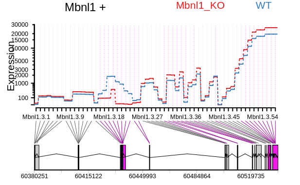

```r
plotDEXSeq(dxr, "Mbnl1", legend=TRUE, cex.axis=1.2, cex=1.3, lwd=2)
```

To display transcripts use displayTranscripts=TRUE

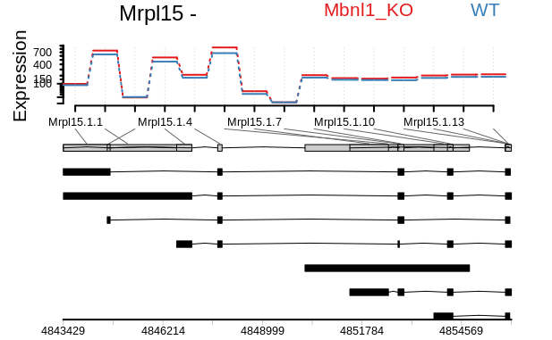

```r
plotDEXSeq(dxr, "Mrpl15", displayTranscripts=TRUE, legend=TRUE, cex.axis=1.2, cex=1.3, lwd=2)
```

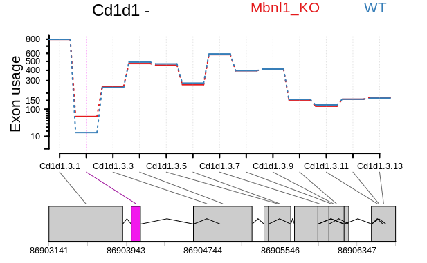

```r
plotDEXSeq(dxr, "Cd1d1", expression=FALSE, splicing=TRUE, legend=TRUE, cex.axis=1.2, cex=1.3, lwd=2)
```

Generate plots for all the significant genes

```r
dxr = dxr[!is.na(dxr$padj),]
    dgene = data.frame(perGeneQValue=perGeneQValue(dxr)) %>% rownames_to_column("groupID")

    dexon = dxr %>% data.frame() %>%
            dplyr::select(-matches("dispersion|stat|countData|genomicData")) %>%
            inner_join(dgene) %>% arrange(perGeneQValue) %>% distinct()
dexon_sig = dexon %>% filter(padj < 0.1)  %>% dplyr::select(-transcripts)
```

Volcano plot to visualize differentially expressed genes

```
One or more p-values is 0. Converting to 10^-1 * current lowest non-zero p-value...
```

[figure not shown]

```r
EnhancedVolcano(dexon_sig, lab = dexon_sig$featureID, x = 'log2fold_WT_Mbnl1_KO', y = 'pvalue', title = 'Volcano Plot', subtitle = 'Mbnl1_KO vs WT (DEXSeq)', FCcutoff = 1, labSize = 4,legendPosition = "right",xlim= c(-4,4),caption = bquote(~Log[2]~ "Fold change cutoff, 2; FDR 10%"))
```

NOTE: EnhancedVolcano package was used to generate the above plot, you will need to install it if not already installed.

### Save Rdata objects

```r
save.image("Mbnl1_KO_Dexseq.RData")
```

## 4.2 Using Limma diffSplice for differential splicing analysis

### 4.2.1 Load libraries

```r
library(limma)
library(edgeR)
```

### 4.2.2 Filtering-

Create a list of features using DGEList, where rows represent genes and columns represent samples. For filtering step, counts are filtered by cpm (counts per million) less than 1 in 3 out of 6 samples.

```r
mycounts = countData$counts
#Change the rownames of the countdata to exon Ids instead of genes for unique rownames.
rownames(mycounts) = exoninfo$ExonID
dge <- DGEList(counts=mycounts)

#Filtering
isexpr <- rowSums(cpm(dge) > 1) >=3
dge <- dge[isexpr,,keep.lib.sizes=FALSE]

#Extract the annotations for only filtered counts
exoninfo = anno %>% filter(ExonID %in% rownames(dge$counts))

#Convert the exoninfo into GRanges object
exoninfo1 <- GRanges (seqnames=  exoninfo$Chr,
ranges= IRanges (start=exoninfo$Start, end=exoninfo$End, width = exoninfo$Width), strand = Rle(exoninfo$Strand))
mcols(exoninfo1)$TranscriptIDs <- exoninfo$TranscriptIDs
mcols(exoninfo1)$Ticker <- exoninfo$Ticker
mcols(exoninfo1)$ExonID <- exoninfo$ExonID
mcols(exoninfo1)$n <- exoninfo$n
mcols(exoninfo1)$GeneID <- exoninfo$GeneID
transcripts_l = strsplit(exoninfo1$TranscriptIDs,  "\\,")
```

### 4.2.3 Normalize the counts-

Normalize the read counts using the TMM method.

```r
dge <- calcNormFactors(dge)
```

### 4.2.4 Create design matrix for comparisons

Use sampleTable as generated in step 4.1.1 and create the design matrix

```r
Treat <- factor(sampleTable$condition)
design <- model.matrix(~0+Treat)
colnames(design) <- levels(Treat)
```

### 4.2.5 Differential expression with voom function

Run voom function of limma to process RNA-seq data and then run linear modelling using lmfit

```r
v <- voom(dge, design, plot=FALSE)
fit <- lmFit(v,design)
fit  <- eBayes(fit)
colnames(fit)
```

```
[1] "Mbnl1_KO" "WT"
```

```r
summary(decideTests(fit))
```

```
       Mbnl1_KO     WT
Down        529    157
NotSig    12591  11778
Up       114625 115810
```

```r
cont.matrix <- makeContrasts(
                Mbnl1_KO_WT = Mbnl1_KO - WT,
                levels=design)
fit2  <- contrasts.fit(fit, cont.matrix)
summary(decideTests(fit2))
```

```
       Mbnl1_KO_WT
Down           449
NotSig      127089
Up             207
```

### 4.2.6 Differential Splicing analysis

Run diffSplice on the fitted model to test the differences in exon retention between wild-type and knockout.

```r
ex <- diffSplice(fit2, geneid = exoninfo1$GeneID, exonid = exoninfo1$ExonID)
```

```
Total number of exons:  127745
Total number of genes:  12414
Number of genes with 1 exon:  1870
Mean number of exons in a gene:  10
Max number of exons in a gene:  119
```

```r
#Check the top splicing results with topSplice
topSplice(ex)
```

|  | GeneID | NExons | P.Value | FDR |
| --- | --- | --- | --- | --- |
| 76034 | Mbnl1 | 47 | 6.297703e-65 | 6.640298e-61 |
| 28373 | Ccdc88c | 31 | 7.516299e-47 | 3.962593e-43 |
| 101862 | Wnk1 | 57 | 1.127501e-42 | 3.962789e-39 |
| 120696 | Dnm2 | 41 | 1.521340e-33 | 4.010253e-30 |
| 1082 | Map4k4 | 55 | 2.008331e-28 | 4.235168e-25 |
| 83387 | Ssbp3 | 34 | 2.865454e-26 | 5.035557e-23 |
| 109013 | Picalm | 40 | 1.212314e-24 | 1.826091e-21 |
| 93357 | Git2 | 42 | 5.511306e-24 | 7.263902e-21 |
| 12528 | Ppp1r12a | 33 | 2.454876e-21 | 2.876023e-18 |
| 61120 | Mark2 | 36 | 3.076270e-21 | 3.243619e-18 |

### 4.2.7 Visualization

Plot the differential splicing result for the top genes and save the results.

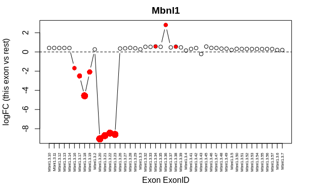

```r
plotSplice(ex, geneid="Mbnl1")
```

```r
#Save the results sorted by logFC
ts <-topSplice(ex, n=Inf, FDR=0.1, test= "t", sort.by = "logFC")
ts %$% GeneID %>% unique %>% length
```

```
[1] 233
```

```r
ts %$% ExonID %>% unique %>% length
```

```
[1] 396
```

```r
#Save the list of top differentially spliced exons at FDR 10%
sig <- ts[ts$FDR<0.1,]
  writexl::write_xlsx(sig,"Mbnl1_diffSplice_significant_genes.xlsx", col_names = TRUE)
```

### Volcano plot-

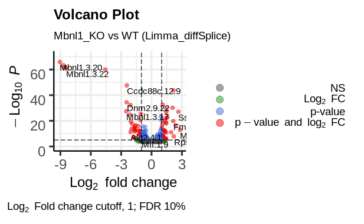

```r
EnhancedVolcano(ts, lab = ts$ExonID, selectLab = head((ts$ExonID),3000),xlab = bquote(~Log[2]~ 'fold change'), x = 'logFC', y = 'P.Value', title = 'Volcano Plot', subtitle = 'Mbnl1_KO vs WT (Limma_diffSplice)', FCcutoff = 1, labSize = 4,legendPosition = "right",caption = bquote(~Log[2]~ "Fold change cutoff, 1; FDR 10%"))
```

```r
Treat <- factor(sampleTable$condition)
design <- model.matrix(~0+Treat)
colnames(design) <- levels(Treat)
```

## 4.3 Using rMATS to identify different types of splicing events

### 4.3.1 Download and Install rMATS

Download and install rMATS v4.1.1 from- (https://github.com/Xinglab/rmats-turbo/releases/download/v4.1.1/rmats_turbo_v4_1_1.tar.gz)

### 4.3.2 Required Files

For pairwise splicing analysis, we will need sorted bam files for all the samples generated after the read alignment step using STAR. prepare text files for two conditions by copying the name of bam files (along with the path) separated by ‘,’ comma. Following commands should be run on the terminal-

```bash
cd bams/
ls -pd "$PWD"/* | grep "WT" | tr '\n' ',' > Wt.txt
ls -pd "$PWD"/* | grep "Mb" | tr '\n' ',' > KO.txt
Move the files to the main working directory
mv *.txt /rMATS_analysis
cd rMATS_analysis
```

### 4.3.3 Run rMATS

Run the python script rmats.py with the two input files generated in the previous step, along with the GTF annotation.

```python
python rmats-turbo/rmats.py --b1 KO.txt --b2 Wt.txt --gtf annotation.gtf -t paired --readLength 50 --nthread 8 --od rmats_out/ --tmp rmats_tmp
```

NOTE:The reference annotation in the form of a GTF file is also required. Make sure both the folder containing bam files (bams/) and annotation file (annotation.gtf) is present in the current path/provide the correct path in the above command. (AS_analysis) Check the parameters if the data is single-end, change the -t option.

The results will be in the specified output directory by the -o option(rmats_out). The –tmp option creates a temporary subdirectory to store all the intermediate files in the analysis. The output folder contains text files for different splicing events with p-values. The summary.txt file presents the table of all the events falling in different categories.

### 4.3.4 Exploring rMATS results

We used a bioconductor package called ‘maser’ to explore the rMATS results.

```r
library(maser)
mbnl1 <- maser("rMATS_analysis/rmats_out/", c("WT", "Mbnl1_KO"), ftype = "JCEC")
#Filtering out events
mbnl1_filt <- filterByCoverage(mbnl1, avg_reads = 5)
```

### 4.3.4 Visualizing rMATS results

```r
#Top splicing events at 5% FDR
mbnl1_top <- topEvents(mbnl1_filt, fdr = 0.05, deltaPSI = 0.1)
mbnl1_top
```

```
A Maser object with 858 splicing events.

Samples description:
Label=WT     n=3 replicates
Label=Mbnl1_KO     n=3 replicates

Splicing events:
A3SS.......... 27 events
A5SS.......... 49 events
SE.......... 634 events
RI.......... 74 events
MXE.......... 74 events
```

```r
#Check the gene events for a particular gene
mbnl1_mapk <- geneEvents(mbnl1_filt, geneS = "Map4k4", fdr = 0.05, deltaPSI = 0.1)
maser::display(mbnl1_mapk, "SE")
```

| ID | GeneID | geneSymbol | PValue | FDR | IncLevelDifference | PSI_1 | PSI_2 | Chr | Strand | exon_target | exon_upstream | exon_downstream |
| --- | --- | --- | --- | --- | --- | --- | --- | --- | --- | --- | --- | --- |
| 17972 | ENSMUSG00000026074 | Map4k4 | 0.000588246839131 | 0.0368576956047187 | -0.168 | 0.407,0.508,0.45 | 0.655,0.568,0.646 | chr1 | + | 40040590-40040751 | 40039691-40039909 | 40042917-40043147 |
| 17974 | ENSMUSG00000026074 | Map4k4 | 3.89729097405e-06 | 0.000538485448688525 | 0.119 | 0.311,0.305,0.35 | 0.177,0.214,0.217 | chr1 | + | 40040590-40040751 | 40039691-40039909 | 40043967-40044073 |
| 17976 | ENSMUSG00000026074 | Map4k4 | 0 | 0 | 0.337 | 0.635,0.538,0.618 | 0.222,0.287,0.27 | chr1 | + | 40042917-40043147 | 40039691-40039909 | 40043967-40044073 |
| 17977 | ENSMUSG00000026074 | Map4k4 | 1.03960440256e-09 | 2.7072263676285e-07 | 0.213 | 0.94,0.873,0.916 | 0.718,0.664,0.709 | chr1 | + | 40042917-40043147 | 40040590-40040751 | 40043967-40044073 |
| 17978 | ENSMUSG00000026074 | Map4k4 | 0 | 0 | 0.332 | 0.615,0.519,0.598 | 0.212,0.271,0.253 | chr1 | + | 40042923-40043147 | 40039691-40039909 | 40043967-40044070 |
| 17979 | ENSMUSG00000026074 | Map4k4 | 1.05136099826e-09 | 2.72633809788287e-07 | 0.219 | 0.938,0.865,0.911 | 0.707,0.659,0.69 | chr1 | + | 40042923-40043147 | 40040590-40040751 | 40043967-40044070 |
| 17980 | ENSMUSG00000026074 | Map4k4 | 0 | 0 | -0.335 | 0.404,0.391,0.315 | 0.709,0.703,0.703 | chr1 | + | 40047491-40047499 | 40046593-40046690 | 40048848-40049023 |
| 55117 | ENSMUSG00000026074 | Map4k4 | 5.20875530693e-05 | 0.00497432496877488 | -0.194 | 0.366,0.453,0.392 | 0.628,0.552,0.612 | chr1 | + | 40040590-40040754 | 40039691-40039909 | 40042917-40043147 |
| 55119 | ENSMUSG00000026074 | Map4k4 | 5.66968546556e-07 | 9.30627600739273e-05 | -0.109 | 0.823,0.737,0.877 | 0.94,0.901,0.923 | chr1 | + | 40050790-40051001 | 40049717-40049837 | 40053266-40053383 |
| 55121 | ENSMUSG00000026074 | Map4k4 | 6.86001491512e-06 | 0.000876562195686255 | -0.162 | 0.701,0.607,0.777 | 0.869,0.829,0.873 | chr1 | + | 40050944-40051001 | 40049717-40049837 | 40053266-40053383 |

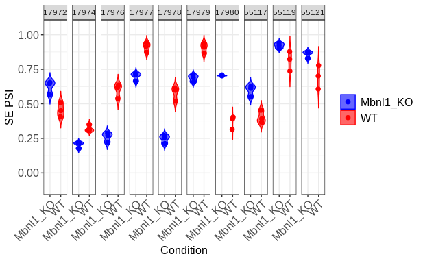

```r
plotGenePSI(mbnl1_mapk, type = "SE", show_replicates = TRUE)
```

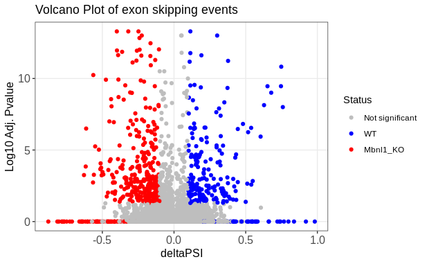

```r
volcano(mbnl1_filt, fdr = 0.05, deltaPSI = 0.1, type = "SE") + xlab("deltaPSI") +ylab("Log10 Adj. Pvalue")+ ggtitle("Volcano Plot of exon skipping events")
```

Install ‘rmats2sashimiplot’ from github and use it to generate Sashimi plot for the splicing events result obtained with rMATS in form of text files. Make sure you go to the rmats2sashimiplot folder to run the python script. Also, double check the path of input files.

```python
python ./src/rmats2sashimiplot/rmats2sashimiplot.py --b1 ../bams/WT_Thymus_1.bam,../bams/WT_Thymus_2.bam,../bams/WT_Thymus_3.bam --b2 ../bams/Mbnl1KO_Thymus_1.bam,../bams/Mbnl1KO_Thymus_2.bam,../bams/Mbnl1KO_Thymus_3.bam -t SE -e ../rMATS_analysis/rmats_out/SE.MATS.JC.txt  --l1 WT --l2 Mbnl1_KO --exon_s 1 --intron_s 5 -o ../rMATS_analysis/rmats2shasmi_output
```

NOTE: This process will take a lot of time as it will generate the Sashimi plot for all the results in the events file (You might want to filter the results and then provide to this step).

Choose the top results (gene names and exons)as displayed by the topEvents function from ‘maser’ and visualize the corresponding Sashimi plot.